# Human Activity Recognition Using Smartphone

The Human Activity Recognition database was built from the recordings of 30 study participants performing activities of daily living (ADL) while carrying a waist-mounted smartphone with embedded inertial sensors. The objective is to classify activities into one of the six activities performed.

The experiments have been carried out with a group of 30 volunteers within an age bracket of 19-48 years. Each person performed six activities (WALKING, WALKING_UPSTAIRS, WALKING_DOWNSTAIRS, SITTING, STANDING, LAYING) wearing a smartphone.

### Attribute information

For each record in the dataset the following is provided:

Triaxial acceleration from the accelerometer (total acceleration) and the estimated body acceleration.

Triaxial Angular velocity from the gyroscope.

A 561-feature vector with time and frequency domain variables.

Its activity label.

An identifier of the subject who carried out the experiment.

```r
library(readr)
library(dplyr)     # For pipe operations
library(glmnet)    # For Lasso
library(e1071)     # for SVM
library(caret)     # Confusion Matrix
library(ggplot2)   # graphs and plots
library(corrplot)
```

### Read Data

1. Activity Id and Labels (WALKING, WALKING_UPSTAIRS, WALKING_DOWNSTAIRS, SITTING, STANDING, LAYING)
2. Column Headers

```r
activities = read.table("./activity_labels.txt", sep = "", col.names = c("Id", "activity"))
activityLabels = as.character(activities$activity)
features = read.table("features.txt", sep = "", col.names = c("Id", "feature"))
attributeNames = features$feature
```

```r
cat("Total no of features - ", length(attributeNames))
```

```
Total no of features -  561
```

3. Train Data

```r
train_X = read.table("./train/X_train.txt", sep="", col.names=attributeNames)
train_y <- read.table("./train/y_train.txt", sep="\n")
names(train_y) = "Activity"
#combining features and activity label
train_y$Activity = as.factor(train_y$Activity)
levels(train_y$Activity) = activityLabels
trainSubjects = read.table("./train/subject_train.txt", sep = "")
names(trainSubjects) = "subject"
#trainSubjects$subject = as.factor(trainSubjects$subject)
train <- cbind(train_X, trainSubjects, train_y)
train_labels <- train$Activity
rm(train_X, train_y)
cat('size of train data ' ,dim(train))
```

```
size of train data  7352 563
```

4. Test Data

```r
test_X <- read.table("./test/X_test.txt", sep="", col.names=attributeNames)
test_y <- read.table("./test/y_test.txt", sep="\n")
names(test_y) = "Activity"
test_y$Activity = as.factor(test_y$Activity)
levels(test_y$Activity) = activityLabels
testSubjects = read.table("./test/subject_test.txt", sep = "")
names(testSubjects) = "subject"
#testSubjects$subject = as.factor(testSubjects$subject)
test <- cbind(test_X, testSubjects, test_y)
rm(test_X, test_y)
cat('size of test data ' , dim(test))
```

```
size of test data  2947 563
```

#### Identify types of variables.

```r
cat_var <- names(train)[which(sapply(train, is.factor))]
num_var <- names(train)[which(sapply(train, is.numeric))]
cat('Total no of Numerical variables are -',length(num_var))
```

```
Total no of Numerical variables are - 562
```

```r
cat('\nTotal no of Categorical variables are -',length(cat_var))
```

```
Total no of Categorical variables are - 1
```

```r
cat('categorical variables are -', cat_var)
```

```
categorical variables are - Activity
```

#### How Activity Variable looks like? -

```r
head(train$Activity)
```

```
[1] STANDING STANDING STANDING STANDING STANDING STANDING
Levels: WALKING WALKING_UPSTAIRS WALKING_DOWNSTAIRS SITTING STANDING LAYING
```

#### Check for NA values in Data

```r
data<-rbind(train,test)
cat('does na value exists')
```

```
does na value exists
```

```r
which(rowSums(is.na(data))==ncol(data))
```

```
named integer(0)
```

It seems there are no NA values in data

### Data Exploration

#### How many activities performed by each Subject?

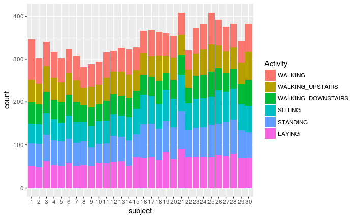

```r
train$Partition <- 'Train'
test$Partition <- 'Test'
all <- rbind(train, test)
all$subject = as.factor(all$subject)
all$Partition = as.factor(all$Partition)
train <- subset(train, select = -c(Partition))
test <- subset(test, select = -c(Partition))
all$subject = as.factor(all$subject)
qplot(data = all , x = subject, fill = Activity)
```

#### All classes seems to be equally distributed, which implies this is not a imbalanced classification problem.

##### Creating readable variable names -

```r
colnames(all) <- gsub("mean", ".Mean.", colnames(all))
colnames(all) <- gsub("std", ".Std.", colnames(all))
colnames(all) <- gsub("^t", "Time.", colnames(all))
colnames(all) <- gsub("\\.t", ".Time.", colnames(all))
colnames(all) <- gsub("^f", "Frequency.", colnames(all))
colnames(all) <- gsub("\\.f", ".Frequency.", colnames(all))
colnames(all) <- gsub("\\(\\)", "", colnames(all))
colnames(all) <- gsub("-", "", colnames(all))
colnames(all) <- gsub("\\.\\.", ".", colnames(all))
colnames(all) <- gsub("\\.\\.", ".", colnames(all))
colnames(all) <- gsub("\\.$", "", colnames(all))
colnames(all) <- gsub("BodyBody", "Body.", colnames(all))
colnames(all) <- gsub("^angle\\.", "Angle.", colnames(all))
colnames(all) <- gsub("Gyro", ".Gyro", colnames(all))
colnames(all) <- gsub("Acc", ".Acc", colnames(all))
colnames(all) <- gsub("Jerk", ".Jerk", colnames(all))
colnames(all) <- gsub("Mag", ".Mag", colnames(all))
#colnames(all) <- gsub("^", "MeanOf.", colnames(all))
colnames(all) <- gsub("(^|[\\.])([[:alpha:]])", "\\1\\U\\2", colnames(all), perl=TRUE)
colnames(all)[c(1:10, 560:564)]
```

```
 [1] "Time.Body.Acc.Mean.X" "Time.Body.Acc.Mean.Y" "Time.Body.Acc.Mean.Z" "Time.Body.Acc.Std.X"  "Time.Body.Acc.Std.Y"  "Time.Body.Acc.Std.Z"  "Time.Body.Acc.Mad.X"
 [8] "Time.Body.Acc.Mad.Y"  "Time.Body.Acc.Mad.Z"  "Time.Body.Acc.Max.X"  "Angle.Y.GravityMean"  "Angle.Z.GravityMean"  "Subject"              "Activity"
[15] "Partition"
```

#### Lets check density of Time of Accleration Mean against X, Y and Z axis

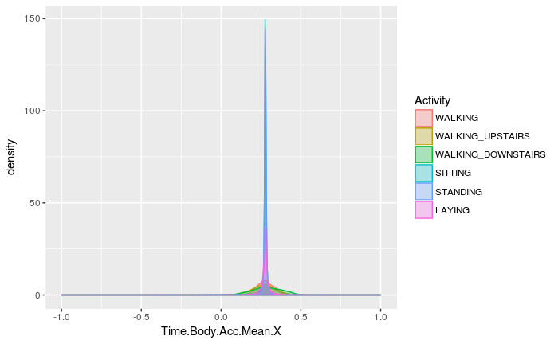

```r
ggplot(all, aes(x=Time.Body.Acc.Mean.X)) + geom_density(aes(group=Activity, colour=Activity, fill=Activity), alpha=0.3)
```

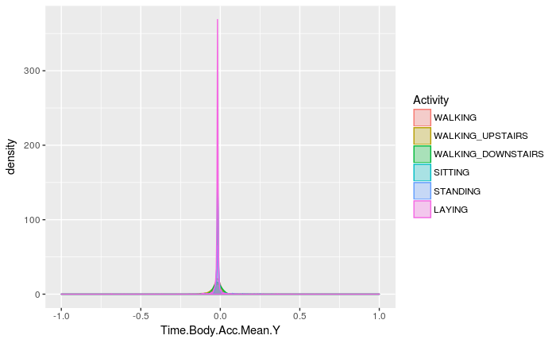

```r
ggplot(all, aes(x=Time.Body.Acc.Mean.Y)) + geom_density(aes(group=Activity, colour=Activity, fill=Activity), alpha=0.3)
```

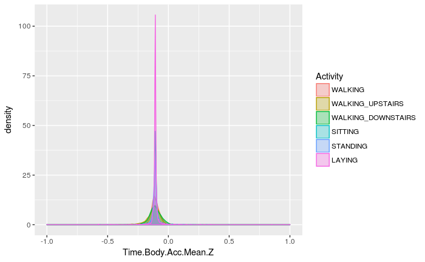

```r
ggplot(all, aes(x=Time.Body.Acc.Mean.Z)) + geom_density(aes(group=Activity, colour=Activity, fill=Activity), alpha=0.3)
```

#### Let’s plot Std against X, Y Z co-ordonates

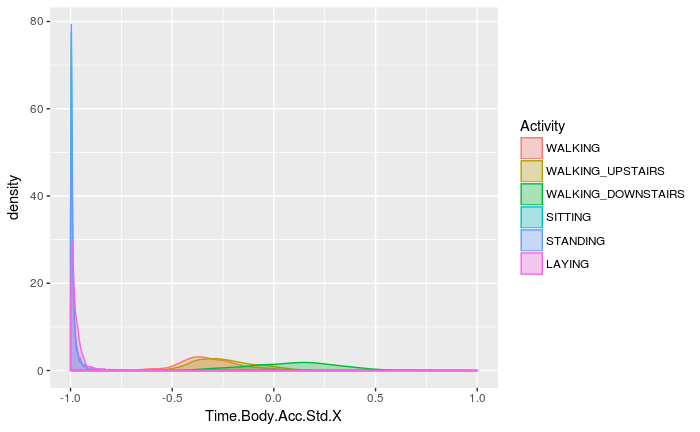

```r
ggplot(all, aes(x=Time.Body.Acc.Std.X)) + geom_density(aes(group=Activity, colour=Activity, fill=Activity), alpha=0.3)
```

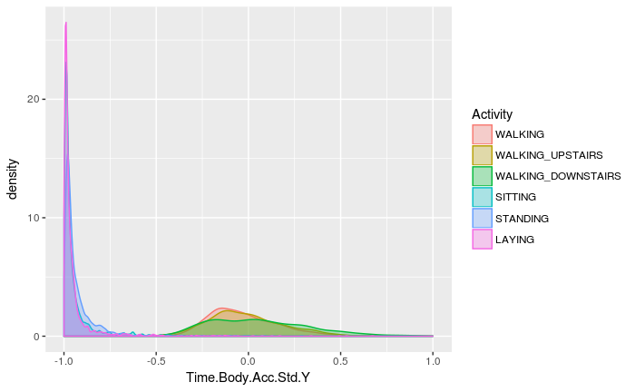

```r
ggplot(all, aes(x=Time.Body.Acc.Std.Y)) + geom_density(aes(group=Activity, colour=Activity, fill=Activity), alpha=0.3)
```

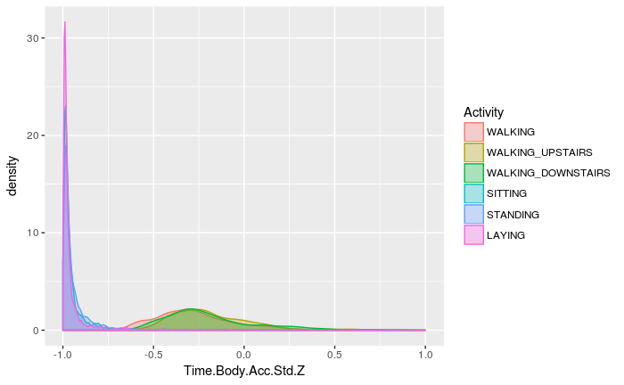

```r
ggplot(all, aes(x=Time.Body.Acc.Std.Z)) + geom_density(aes(group=Activity, colour=Activity, fill=Activity), alpha=0.3)
```

#### In general, while Walking on straigth surface or Stair Case, Time deviation is high

##### Lets’ plot corleation between Time Mean and Time std.

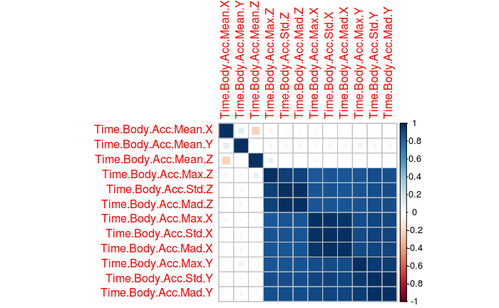

```r
corr_data = all[,1:12]
correlations <- cor(corr_data)
corrplot(correlations, method="square", order="hclust")
```

#### Here we only ploted first 12 variables, many variables are highly correlated.

#### Thus working on high dimentions (561 independent variables) will be time consuming, Lets’ apply Dimention Reduction Techniques -

### PCA or Lasso

Applying nameing transformation to entire dataset

```r
nameVector <- make.names(names(data),unique=TRUE)
names(data) <- nameVector
dim(data)
```

```
[1] 10299   563
```

Test - Train split again

```r
train <- data[1:7352,]
test <- data[-c(1:7352),]
dim(train)
```

```
[1] 7352  563
```

## Principal Component Analysis ( PCA)

##### Data has high dimentions (561), As we saw some features are highly correlated, all of them might not be important features, we can use PCA to reduce dimention of data.

#### PCA will help us to create Pricincipal components which will cover maximum variance with less number of features.

```r
pca <- prcomp(train[,-c(563)], center=TRUE, scale=TRUE)
#Calculate Variance covered by each Principal Component.
pca.variance <- pca$sdev^2
# Canculate Percentage Variance
pca.pervarriance <- pca.variance / sum(pca.variance)
```

#### As all of them are numerical variables, alternative to this is -

1. to check correlation between Independent variables.
2. Plot scatter plot between all Independent Variables.
3. Remove highly colinear variables.

#### Plot How much % of variance is covered by each Principal Component

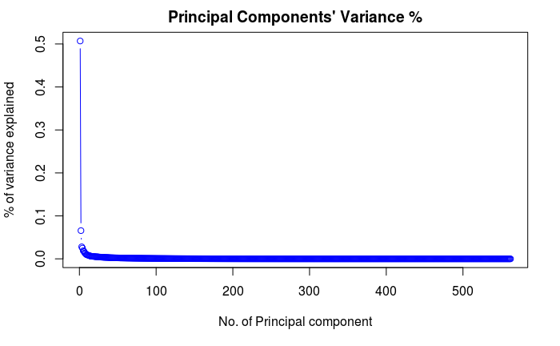

```r
plot(pca.pervarriance,
     xlab="No. of Principal component",
     ylab="% of variance explained",
     type='b',
     main="Principal Components' Variance %",col="blue")
```

First Principal Component explains around 50% variance of actual data

#### Let’s plot cumulative Addition of variance and check how many components cover 98% of variance.

```r
plot(cumsum(pca.pervarriance),
     xlab="No. of Principal component",
     ylab="Cumulative % of variance explained",
     type='b',main="Principal Components' Variance %",col="blue")
abline(h=0.98)
```

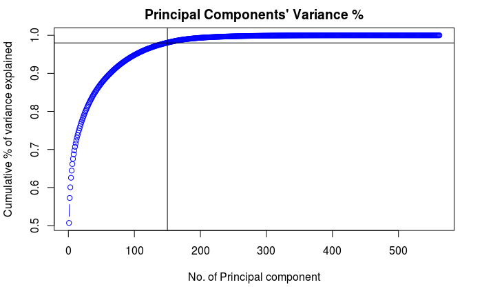

```r
abline(v=150)
```

First 150 Pincipal Components cover 98% of variance of data and First 100 Components cover 95% of variance of data

We can try various permutaions using K-fold

#### Create train set from first 100 pca components.

```r
train.data <- data.frame(activity=train$Activity, pca$x)
train.data <- train.data[,1:101]
dim(train.data)
```

```
[1] 7352  101
```

```r
train.data[1,]
```

|  | activity | PC1 | PC2 | PC3 | PC4 | PC5 | PC6 | PC7 | PC8 | PC9 | PC10 | PC11 | PC12 | PC13 | PC14 | PC15 | PC16 | PC17 | PC18 | PC19 | PC20 | PC21 | PC22 | PC23 | PC24 | PC25 | PC26 | PC27 | PC28 | … |
| --- | --- | --- | --- | --- | --- | --- | --- | --- | --- | --- | --- | --- | --- | --- | --- | --- | --- | --- | --- | --- | --- | --- | --- | --- | --- | --- | --- | --- | --- | --- |
| 1 | STANDING | 16.12678 | 2.164918 | -3.111919 | 0.2726598 | 6.79271 | 4.125931 | -2.987542 | -5.057544 | -0.7153999 | 3.640044 | -0.09595024 | -0.8873176 | 1.134373 | -1.574336 | -2.624695 | 0.9107246 | 1.566202 | -3.948178 | -2.201682 | -0.07006538 | 2.754413 | -3.347837 | -0.216407 | -1.808402 | -0.428326 | 4.022791 | 0.6382091 | -0.8520998 | … |

##### Apply basic SVM model on PCA data. As we have multiple Target Variables problem, we will try SVM

```r
svm_model <- svm(activity ~ ., data=train.data)
svm_model
```

```
Call:
svm(formula = activity ~ ., data = train.data)


Parameters:
   SVM-Type:  C-classification
 SVM-Kernel:  radial
       cost:  1
      gamma:  0.01

Number of Support Vectors:  4230
```

##### Predict PCA components for test data as well - Pick first 100 Principal Components of Test data.

```r
test.data <- predict(pca, newdata=test)
test.data <- as.data.frame(test.data)
test.data <- test.data[,1:100]
test_actual <- test$Activity
```

##### Predict Values for basic SVM

Create Confusion Matrix

```r
test_pred <- predict(svm_model, test.data, type="class")
confusionMatrix(test_pred, test_actual)
```

```
Confusion Matrix and Statistics

                    Reference
Prediction           WALKING WALKING_UPSTAIRS WALKING_DOWNSTAIRS SITTING STANDING LAYING
  WALKING                477               33                  3       0        1      0
  WALKING_UPSTAIRS         0              416                  8       1        0      0
  WALKING_DOWNSTAIRS      19               22                409       3        1      3
  SITTING                  0                0                  0     420       27      0
  STANDING                 0                0                  0      63      503      0
  LAYING                   0                0                  0       4        0    534

Overall Statistics

               Accuracy : 0.9362
                 95% CI : (0.9268, 0.9448)
    No Information Rate : 0.1822
    P-Value [Acc > NIR] : < 2.2e-16

                  Kappa : 0.9234
 Mcnemar's Test P-Value : NA

Statistics by Class:

                     Class: WALKING Class: WALKING_UPSTAIRS Class: WALKING_DOWNSTAIRS Class: SITTING Class: STANDING Class: LAYING
Sensitivity                  0.9617                  0.8832                    0.9738         0.8554          0.9455        0.9944
Specificity                  0.9849                  0.9964                    0.9810         0.9890          0.9739        0.9983
Pos Pred Value               0.9280                  0.9788                    0.8950         0.9396          0.8887        0.9926
Neg Pred Value               0.9922                  0.9782                    0.9956         0.9716          0.9878        0.9988
Prevalence                   0.1683                  0.1598                    0.1425         0.1666          0.1805        0.1822
Detection Rate               0.1619                  0.1412                    0.1388         0.1425          0.1707        0.1812
Detection Prevalence         0.1744                  0.1442                    0.1551         0.1517          0.1921        0.1826
Balanced Accuracy            0.9733                  0.9398                    0.9774         0.9222          0.9597        0.9964
```

##### Accuracy of Basic Non Linear Kernal’s Model is 93.62%

#### Training the SVM model with different HyperParameter

Caret package provides train() method for training our data for various algorithms. We just need to pass different parameter values for different algorithms. Before train() method, we will first use trainControl() method. It controls the computational nuances of the train() method.

#### Let’s try linear Kernal -

```r
trctrl <- trainControl(method = "repeatedcv", number = 10, repeats = 3)
set.seed(3233)
svm_Linear <- train(activity ~., data = train.data, method = "svmLinear",
                 trControl=trctrl,
                 preProcess = c("center", "scale"),
                 tuneLength = 10)
```

Trained SVM model result

```r
svm_Linear
```

```
Support Vector Machines with Linear Kernel

7352 samples
 100 predictors
   6 classes: 'WALKING', 'WALKING_UPSTAIRS', 'WALKING_DOWNSTAIRS', 'SITTING', 'STANDING', 'LAYING'

Pre-processing: centered (100), scaled (100)
Resampling: Cross-Validated (10 fold, repeated 3 times)
Summary of sample sizes: 6618, 6615, 6616, 6616, 6619, 6617, ...
Resampling results:

  Accuracy   Kappa
  0.9727977  0.9672558

Tuning parameter 'C' was held constant at a value of 1
```

```r
test_pred <- predict(svm_Linear, newdata = test.data)
confusionMatrix(test_pred, test_actual )
```

```
Confusion Matrix and Statistics

                    Reference
Prediction           WALKING WALKING_UPSTAIRS WALKING_DOWNSTAIRS SITTING STANDING LAYING
  WALKING                482               68                 11       0        1      0
  WALKING_UPSTAIRS         5              376                 30       1        0      0
  WALKING_DOWNSTAIRS       9               27                379       0        0      0
  SITTING                  0                0                  0     409       31      0
  STANDING                 0                0                  0      80      500      0
  LAYING                   0                0                  0       1        0    537

Overall Statistics

               Accuracy : 0.9104
                 95% CI : (0.8995, 0.9205)
    No Information Rate : 0.1822
    P-Value [Acc > NIR] : < 2.2e-16

                  Kappa : 0.8923
 Mcnemar's Test P-Value : NA

Statistics by Class:

                     Class: WALKING Class: WALKING_UPSTAIRS Class: WALKING_DOWNSTAIRS Class: SITTING Class: STANDING Class: LAYING
Sensitivity                  0.9718                  0.7983                    0.9024         0.8330          0.9398        1.0000
Specificity                  0.9674                  0.9855                    0.9858         0.9874          0.9669        0.9996
Pos Pred Value               0.8577                  0.9126                    0.9133         0.9295          0.8621        0.9981
Neg Pred Value               0.9941                  0.9625                    0.9838         0.9673          0.9865        1.0000
Prevalence                   0.1683                  0.1598                    0.1425         0.1666          0.1805        0.1822
Detection Rate               0.1636                  0.1276                    0.1286         0.1388          0.1697        0.1822
Detection Prevalence         0.1907                  0.1398                    0.1408         0.1493          0.1968        0.1826
Balanced Accuracy            0.9696                  0.8919                    0.9441         0.9102          0.9534        0.9998
```

##### Lets try to change C hyper Tuning Parameter with linear Kernal, using Grid CV

Change in C will define how much miss-classfication to allow. High C value might tend to Overfitting

```r
grid <- expand.grid(C = c(0,0.01, 0.05, 0.1, 0.25, 0.5, 0.75, 1, 1.25, 1.5, 1.75, 2,5))
set.seed(3233)
svm_Linear_Grid <- train(activity ~., data = train.data, method = "svmLinear",
                    trControl=trctrl,
                    preProcess = c("center", "scale"),
                    tuneGrid = grid,
                    tuneLength = 10)

svm_Linear_Grid
```

[output not shown]

```r
plot(svm_Linear_Grid)
```

[output not shown]

```r
test_pred_grid <- predict(svm_Linear_Grid, newdata = test.data)

test_pred_grid
```

[output not shown]

```r
confusionMatrix(test_pred_grid, test_actual )
```

[output not shown]

#### SVM with Non Linear Kernal

```r
et.seed(3233)
svm_Radial <- train(activity ~., data = train.data, method = "svmRadial",
  trControl=trctrl,
  preProcess = c("center", "scale"),
  tuneLength = 10)

svm_Radial
```

[output not shown]

```r
plot(svm_Radial)
```

[output not shown]

```r
test_pred_Radial <- predict(svm_Radial, newdata = test.data)
confusionMatrix(test_pred_Radial, test_actual )
```

[output not shown]

##### HyperParameter tuning for non linear kernal using K fold

```r
grid_radial <- expand.grid(sigma = c(0,0.01, 0.02, 0.025, 0.03, 0.04, 0.05, 0.06, 0.07,0.08, 0.09, 0.1, 0.25, 0.5, 0.75,0.9),
 C = c(0,0.01, 0.05, 0.1, 0.25, 0.5, 0.75, 1, 1.5, 2, 5))
set.seed(3233)
svm_Radial_Grid <- train(activity ~., data = train.data, method = "svmRadial",
                    trControl=trctrl,
                    preProcess = c("center", "scale"),
                    tuneGrid = grid_radial,
                    tuneLength = 10)

plot(svm_Radial_Grid)
```

[output not shown]

```r
test_pred_Radial_Grid <- predict(svm_Radial_Grid, newdata = test.data)

confusionMatrix(test_pred_Radial_Grid, test_actual )
```

[output not shown]

## Lasso Regression - Classification

### Lasso Feature Selection

With 561 features, it’s important to reduce the feature-set to avoid overfitting and to create a sensical model. The more features you have, the easier it is to create a model that trains well, but may not do so well with test data. To learn more about these problems, checkout the bias-variance trade-off and the curse of dimensionality. Lasso selection works by reducing the coefficients of certain features towards (and exactly) 0. The higher the lambda, the faster this will happen. A sufficiently high lamba would set all features to 0, meaning only the coefficient will be used in the model (a simple mean, for example, in regression).

# To be Continued….

### This is not the end, accuracy of model can be improved by trying different types of model and hyperparameter tuning, with different classification algorithms.